# 133 final project

Jiahua Zou

*Source file* ⇒ final_project.Rmd

```r
#before this step, we use wget to scrap the spreadsheets of Chinese census of 2010 and 2000 from the official website of Chinese Bureau of Statistics. It is an XLSX document so we open it with GoogleSlide, use GOOGLETRANSLATE function to translate all Chinese into English, and then download it as CSV file.

census2010 <- read.csv("/Users/jiahua/Documents/Berkeley/stat133/final project/10census.csv") # read data in as csv file
census2000 <- read.csv("/Users/jiahua/Documents/Berkeley/stat133/final project/00census.csv")
census2010_age <- read.csv("/Users/jiahua/Documents/Berkeley/stat133/final project/10census_age.csv")
census2000_age <- read.csv("/Users/jiahua/Documents/Berkeley/stat133/final project/00census_age.csv")
census2010_ethnic <- read.csv("/Users/jiahua/Documents/Berkeley/stat133/final project/10census_ethnic.csv")
```

```r
modifyCSV <- function(csv) {
  csv <- csv %>% select(c(1, 6, 7, 8, 9)) #only select columns concerning total population, ignoring the complication of household

  csv <- csv %>% filter(grepl("[[:digit:]]", X.4))
  # filter out rows that are empty

  colnames(csv) <- c("Area", "Total", "Male", "Female", "Ratio")
  # Rename columns

  return(csv)
}

modifyCSV_age <- function(csv) {
  csv <- csv %>% filter(grepl("[[:digit:]]", X.3)) %>%
    select(c(1, 3, 4, 5, 6, 7, 8, 9))

  colnames(csv) <- c("Age", "Total", "Male", "Female", "Total_Ratio", "Male_Ratio", "Female_Ratio", "Gender_Ratio")

  csv <- csv %>% filter(grepl("^[[:digit:]]*$", as.character(Age)))
  return(csv)
}
```

```r
census2010_final <- modifyCSV(census2010)
census2000_final <- modifyCSV(census2000)
census2000_final$Area = census2010_final$Area #Create a key that we can use later to join two tables together
combined_census <- census2000_final %>% left_join(census2010_final, by = "Area")
```

data wrangling with census data base on age and add a column year, which specifeis how many babies are born at that year, calculating from existing data

```r
census2010_age_1 <- census2010_age %>% modifyCSV_age() %>%
  mutate(Year = c(2010:1911)) %>% filter(Year >= 1980) %>% arrange(Year)

census2010_age_2 <- census2010_age_1 %>% gather(key = Gender, value = Population,
                                              Male, Female) %>% select(Year, Gender, Population)
```

create a graph that shows the effect of one chile policy from 1980 when one-childe policy is introduced, thourgh 1991 when it became strictly enforced, till 2010.

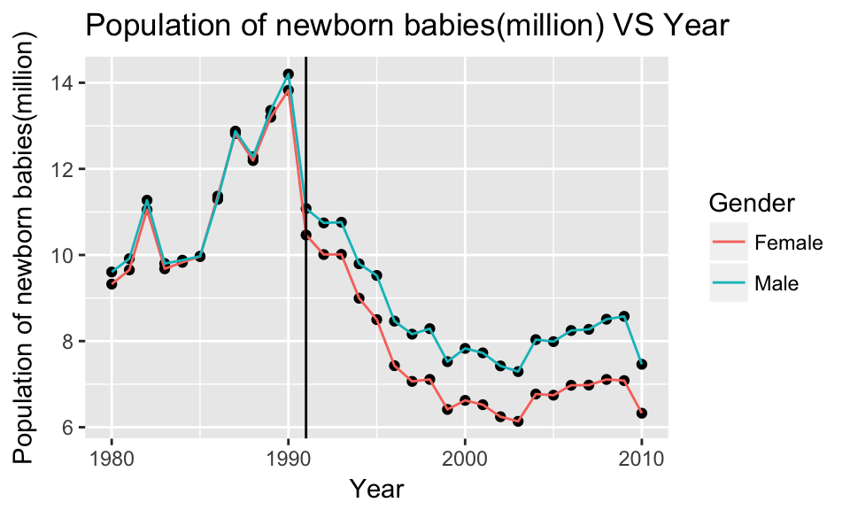

```r
graph1 <- census2010_age_2 %>% ggplot(aes(x = Year, y = as.numeric(as.character(Population)) / 1000000)) + geom_point() +
  geom_line(aes(color = Gender)) + labs(title = "Population of newborn babies(million) VS Year",y = "Population of newborn babies(million)") + geom_vline(xintercept = 1991)


print(graph1)
```

data wrangling to try to show change in gender ratio

```r
census2010_age_3 <- census2010_age_1 %>% gather(key = Gender, value = Ratio, Male_Ratio, Female_Ratio) %>% select(Year, Gender, Ratio, Total_Ratio) %>%
  mutate(Gender = ifelse(as.character(Gender) == "Male_Ratio", "Male", "Female"))
```

create stack columns graph that visualize the change

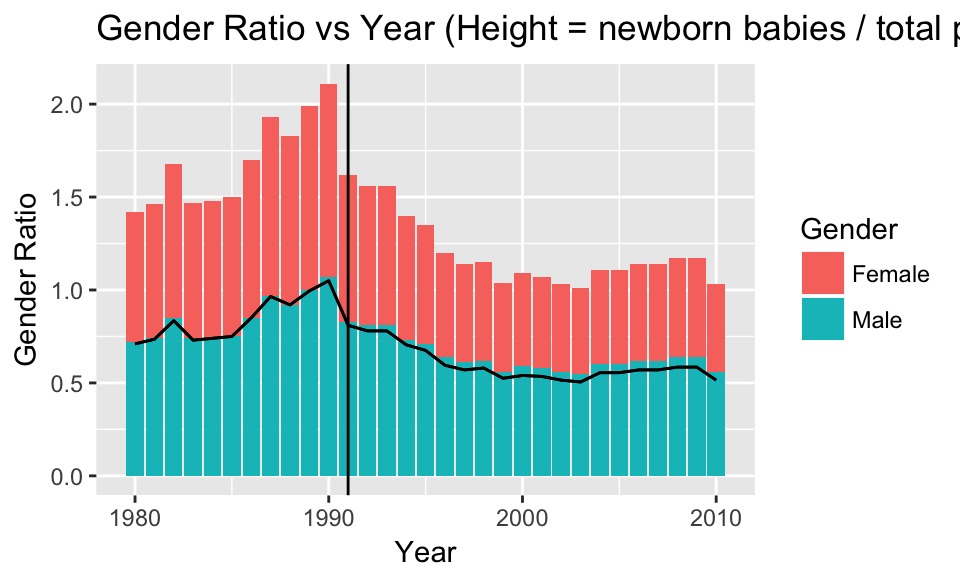

```r
graph2 <- census2010_age_3 %>% ggplot(aes(x = Year, y = as.numeric(as.character(Ratio)), fill = Gender)) +
  geom_bar(stat = "identity") + geom_vline(xintercept = 1991) +
  labs(title = "Gender Ratio vs Year (Height = newborn babies / total population)", y = "Gender Ratio") +
  geom_line(aes(x = Year, y = as.numeric(as.character(Total_Ratio))/2)) #create a line that indicate perfect gender balance

print(graph2)
```

data wrangling to try to augment the change in gender ratio of newborn babies

```r
census2010_age_4 <- census2010_age_1 %>% mutate(Male = as.numeric(as.character(Male))/ as.numeric(as.character(Total))) %>% mutate(Female = 1 - Male) %>%
  gather(key = Gender, value = Ratio, Male, Female) %>% select(Year, Gender, Ratio)
```

create graph that shows change of gender ratio of babies thourghtout 30 years

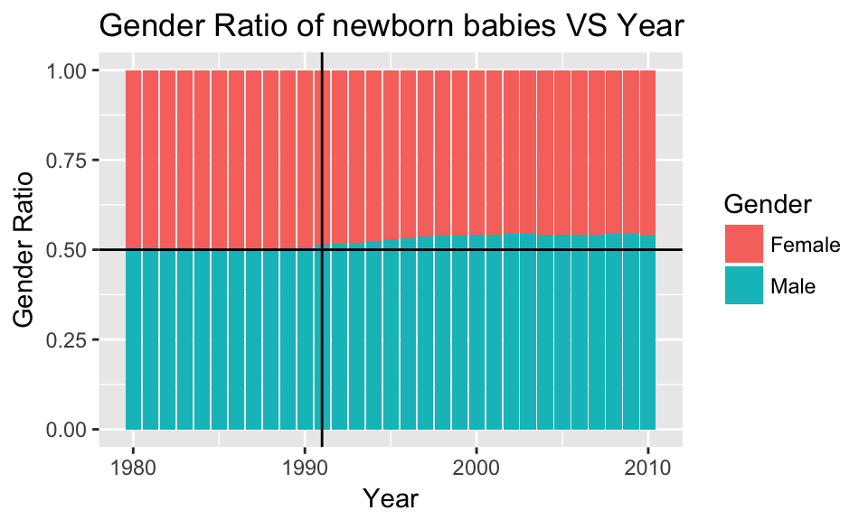

```r
graph3 <- census2010_age_4 %>% ggplot(aes(x = Year, y = Ratio, fill = Gender)) +
  geom_bar(stat = "identity") + geom_hline(yintercept = 0.5) + geom_vline(xintercept = 1991) + labs(title = "Gender Ratio of newborn babies VS Year", y = "Gender Ratio")

print(graph3)
```

data wrangling to get data base on ethnicity. Since ethnic minority are not affected by one child policy, we choose the most populous 6 ethnic minorities group

```r
census2010_ethnic_1 <- census2010_ethnic %>% select(c(Age, Han, HanMale, HanFemale, Hui, HuiMale, HuiFemale, Tibetan, TibetanMale, TibetanFemale, Mongolian, MongolianMale, MongolianFemale, Uyghur, UyghurMale, UyghurFemale, Korean, KoreanMale, KoreanFemale)) %>% filter(grepl("^[[:digit:]]*$", as.character(Age))) %>%
  mutate(Year = 2010:1911) %>% filter(Year >= 1980) %>% arrange(Year) %>%
  gather(key = ethnic, value = total, Han, Hui, Tibetan, Mongolian, Uyghur, Korean) %>%
  mutate(female = ifelse(ethnic == "Han", HanFemale,
                       ifelse(ethnic == "Hui", HuiFemale,
                              ifelse(ethnic == "Tibetan", TibetanFemale,
                                     ifelse(ethnic == "Mongolian", MongolianFemale,
                                            ifelse(ethnic == "Uyghur", UyghurFemale, KoreanFemale)))))) %>% mutate(male = total - female) %>%
  select(Year, ethnic, total, male, female) %>%
  gather(key = gender, value = pop, male, female)

View(census2010_ethnic_1)
```

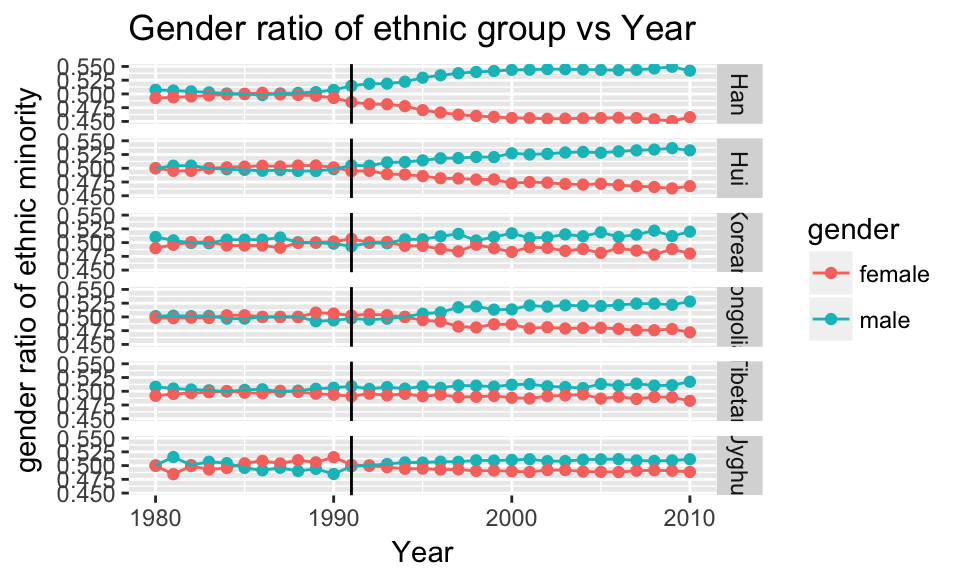

```r
graph4 <- census2010_ethnic_1 %>% ggplot(aes(x = Year, y = pop / total, color = gender)) + facet_grid(ethnic ~ .) + geom_point() + geom_line() +
  geom_vline(xintercept = 1991) + labs(title = "Gender ratio of ethnic group vs Year", y = "gender ratio of ethnic minority")

print(graph4)
```

To compare Han people who are affected by one child policy, we compute Gender ratio

```r
census2010_ethnic_3 <- census2010_ethnic_1 %>% mutate(pop = pop / total)
lm(pop ~ Year + ethnic, census2010_ethnic_3) %>% summary()
```

```
##
## Call:
## lm(formula = pop ~ Year + ethnic, data = census2010_ethnic_3)
##
## Residuals:
##       Min        1Q    Median        3Q       Max
## -0.049383 -0.008671  0.000000  0.008671  0.049383
##
## Coefficients:
##                   Estimate Std. Error t value Pr(>|t|)
## (Intercept)      5.000e-01  2.041e-01    2.45   0.0147 *
## Year             4.867e-18  1.023e-04    0.00   1.0000
## ethnicHui        4.830e-18  3.169e-03    0.00   1.0000
## ethnicKorean    -9.715e-19  3.169e-03    0.00   1.0000
## ethnicMongolian -5.154e-18  3.169e-03    0.00   1.0000
## ethnicTibetan   -6.624e-18  3.169e-03    0.00   1.0000
## ethnicUyghur    -1.714e-18  3.169e-03    0.00   1.0000
## ---
## Signif. codes:  0 '***' 0.001 '**' 0.01 '*' 0.05 '.' 0.1 ' ' 1
##
## Residual standard error: 0.01765 on 365 degrees of freedom
## Multiple R-squared:  9.545e-30,  Adjusted R-squared:  -0.01644
## F-statistic: 5.806e-28 on 6 and 365 DF,  p-value: 1
```

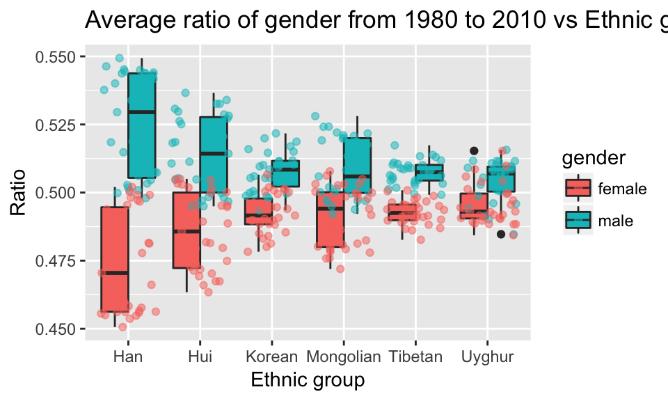

```r
graph5 <- census2010_ethnic_3 %>% ggplot(aes(x = ethnic, y = pop, fill = gender)) + geom_boxplot() + geom_jitter(aes(color = gender), alpha = 0.5) + labs(title = "Average ratio of gender from 1980 to 2010 vs Ethnic group", y = "Ratio", x = "Ethnic group")

print(graph5)
```

Per Capita GDP-plot

```r
GDP<-read.csv("/Users/jiahua/Documents/Berkeley/stat133/final project/GDP.csv")
colnames(GDP)[1]<-"Area"

GDP_new <- GDP[-c(1:7),c(1,2)] %>%
  mutate(X=as.numeric(as.character(X)))%>%
  mutate(Area=as.character(Area)) %>%
  mutate(Area=gsub("^[ ]*","",Area)) %>%
  filter(X!=1)

census10<- census2010_final %>%
  mutate(Area=as.character(Area)) %>%
  mutate(Total=as.numeric(as.character(Total))) %>%
  mutate(Ratio=as.numeric(as.character(Ratio))) %>%
  mutate(Male=as.numeric(as.character(Male))) %>%
  mutate(Female=as.numeric(as.character(Female)))

GDP_join <- GDP_new %>%
  left_join(census10) %>%
  mutate(pcGDP=X/Total)
```

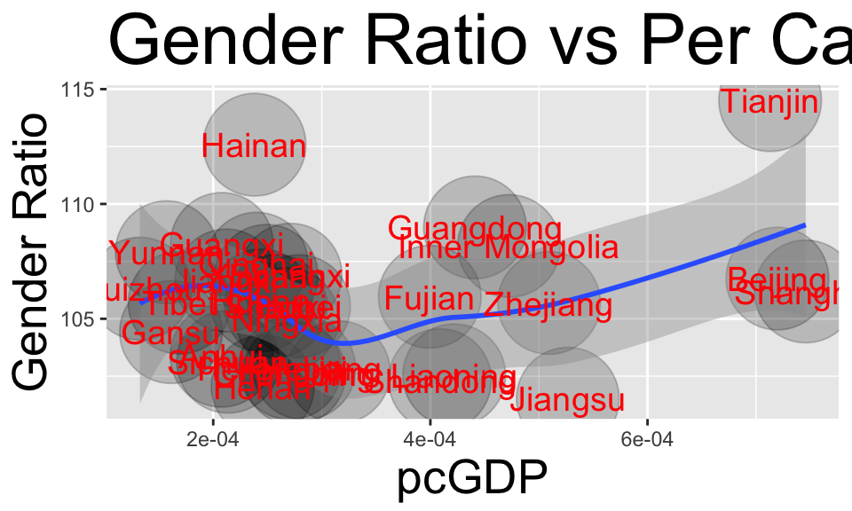

```r
p<- GDP_join %>%
  ggplot(aes(x = pcGDP,y = Ratio))+
  geom_point(alpha=0.2,size=20)+
  geom_smooth(method = "loess")+
  labs(title = "Gender Ratio vs Per Capita GDP",y="Gender Ratio")+
  geom_text(aes(label=Area),col="red",size=5)+
  theme(plot.title = element_text(size=30), axis.title=element_text(size=20))
p
```

Table of illiterate population and ratio of each province

```r
illit <- read.csv("/Users/jiahua/Documents/Berkeley/stat133/final project/illiterate.csv")
colnames(illit) <- c("Area","IP00","IP10","IR00","IR10")

illit_new<- illit %>%
  mutate(Area=as.character(Area)) %>%
  mutate(Area=gsub("National Total","The Whole Country",Area)) %>%
  mutate(IR10=as.numeric(as.character(IR10))) %>%
  mutate(IR00=as.numeric(as.character(IR00)))
```

data wrangling that filter out NA value and join the table of illiterate and census data

```r
illit_new_1 <- illit_new %>% filter(IP10 != "NA") %>% filter(IP00 != 2000)
illit_new_1$Area <- census10$Area
illit_join <- illit_new_1 %>% right_join(census10)
```

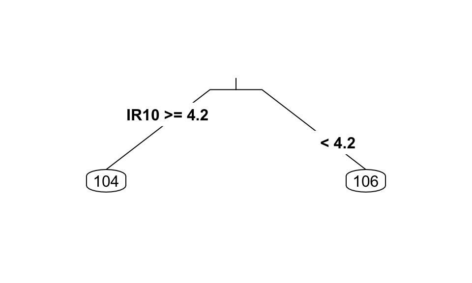

```r
library(rpart.plot)
illit_2 <- illit_join %>% filter(IP00 != 8507)
gdp_illit_pop <- illit_2 %>% left_join(GDP_join) %>%
  filter(!Area %in% c("Guangxi", "Guizhou", "Xinjiang", "Tibet", "Yunnan", "Ningxia", "Qinghai")) %>% arrange(desc(pcGDP)) %>%
  mutate(status = ifelse(pcGDP >= pcGDP[12], "developed", "underdeveloped")) %>%
  arrange(desc(Ratio))
rpart(Ratio ~ IR10, gdp_illit_pop) %>% rpart.plot::prp(type=3)
```

```r
lm(Ratio ~ IR10, gdp_illit_pop) %>% summary()
```

```
##
## Call:
## lm(formula = Ratio ~ IR10, data = gdp_illit_pop)
##
## Residuals:
##     Min      1Q  Median      3Q     Max
## -3.8500 -2.6987  0.0393  1.0104  8.5086
##
## Coefficients:
##             Estimate Std. Error t value Pr(>|t|)
## (Intercept) 106.7991     1.4881  71.767   <2e-16 ***
## IR10         -0.3751     0.3580  -1.048    0.306
## ---
## Signif. codes:  0 '***' 0.001 '**' 0.01 '*' 0.05 '.' 0.1 ' ' 1
##
## Residual standard error: 3.254 on 22 degrees of freedom
## Multiple R-squared:  0.04753,    Adjusted R-squared:  0.00424
## F-statistic: 1.098 on 1 and 22 DF,  p-value: 0.3061
```

We assume that the developed province will be the most balance. However, as the graph suggests, it looks like there is not much difference. We assume that it is because there are a lot of labor from other less developed province, who would like to work at these relatively affluent province, which is a China-only phenomenon. Therefore, we introduce a new concept called Hukou which is also a Chinese concept. It basically refers to the populaion that settle in a particular area. Thus we hope to exclude the effect of male labor who migrant a lot. The following data table is from the same resource as previous and undergo the same pre-processing such as translation.

```r
census2010_hukou <- read.csv("/Users/jiahua/Documents/Berkeley/stat133/final project/10census_hukou.csv")

census2010_hukou_1 <- census2010_hukou %>% select(c(X, X.4, X.5, X.6)) %>%
  filter(grepl("[[:digit:]]", X.4)) %>% filter(X != "The whole country") %>%
  mutate(X = as.character(X))

colnames(census2010_hukou_1) <- c("Area", "Subtotal", "Male", "Female")

GDP_2 <- GDP_join %>% select(c(Area, X, pcGDP))

Hukou_GDP <- census2010_hukou_1 %>% left_join(GDP_2) %>%
  mutate(Male = as.numeric(as.character(Male))) %>%
  mutate(Female = as.numeric(as.character(Female))) %>%
  mutate(ratio = Male / Female) %>% filter(!Area %in% c("Guangxi", "Guizhou", "Xinjiang", "Tibet", "Yunnan", "Ningxia", "Qinghai")) %>% arrange(desc(pcGDP)) %>%
  mutate(status = ifelse(pcGDP >= pcGDP[8], "developed",
                         ifelse(pcGDP >= pcGDP[16], "developing", "underdeveloped"))) %>%
  arrange(desc(ratio))
Hukou_GDP_1 <- illit_2 %>% select(c(Area, IR10)) %>% right_join(Hukou_GDP)
lm(ratio ~ pcGDP + status, Hukou_GDP_1) %>% summary()
```

```
##
## Call:
## lm(formula = ratio ~ pcGDP + status, data = Hukou_GDP_1)
##
## Residuals:
##       Min        1Q    Median        3Q       Max
## -0.035422 -0.014076 -0.003204  0.010014  0.093156
##
## Coefficients:
##                        Estimate Std. Error t value Pr(>|t|)
## (Intercept)            1.060960   0.040985  25.886   <2e-16 ***
## pcGDP                -73.555879  69.966624  -1.051    0.306
## statusdeveloping      -0.004114   0.022654  -0.182    0.858
## statusunderdeveloped   0.008039   0.027923   0.288    0.776
## ---
## Signif. codes:  0 '***' 0.001 '**' 0.01 '*' 0.05 '.' 0.1 ' ' 1
##
## Residual standard error: 0.02778 on 20 degrees of freedom
## Multiple R-squared:  0.2579, Adjusted R-squared:  0.1466
## F-statistic: 2.317 on 3 and 20 DF,  p-value: 0.1064
```

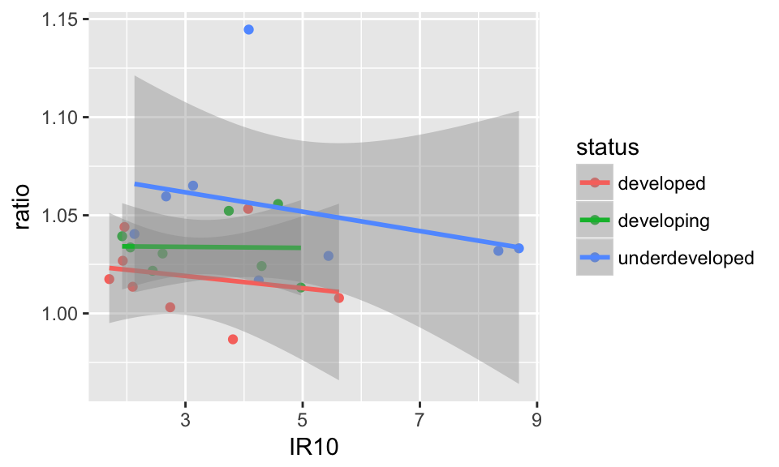

```r
graph7 <- Hukou_GDP_1 %>% ggplot(aes(x = IR10, y = ratio, group = status)) +
  geom_point(aes(color = status)) + geom_smooth(aes(color = status), method = "lm")

print(graph7)
```

```r
library(rvest)
SetOfTables <-
  "https://en.wikipedia.org/wiki/List_of_countries_by_sex_ratio" %>%
  read_html() %>%
  html_nodes(xpath = '//*[@id="mw-content-text"]/table') %>%
  html_table(fill=TRUE)
```